# Quiz 2

## Question 1

The variance of a distribution of the average of an IID draw of `n` observations from a population with mean `\mu` and variance `\sigma^2` is `\sigma^2/n`

## Question 2

Suppose the diastolic blood pressures (DBPs) for men aged 35-44 are normally distributed with a mean of 80 (mm Hg) and a standard deviation of 10. What is the probability that a random 35-44 year old has a DBP less than 70?

This can be determined using the `pnorm` function in R.

```r
pnorm(70, mean=80, sd=10, lower.tail=TRUE)
```

```
## [1] 0.1587
```

## Question 3

Suppose Brain volume for adult women is normally distributed with a mean of about 1,100 cc for women with a standard deviation of 75 cc. What brain volume represents the 95th percentile?

This can be determined using the `qnorm` function in R.

```r
population.mean <- 1100
population.sd <- 75
qnorm(0.95, mean=population.mean, sd=population.sd, lower.tail=TRUE)
```

```
## [1] 1223
```

## Question 4

Consider the sample mean of 100 random adult women from this population. What is the 95th percentile of the distribution of that sample mean?

```r
n.samples <- 100
```

The expected mean obtained from sampling from a normally distributed population is the same as the mean of the population. So, the expected sample mean is 1100 cc.

```r
sample.mean <- population.mean
```

The expected standard deviation of the sample mean give a sample size of `n.samples` is `population.sd/sqrt(n.sample)`. Therefore, the expected standard deviation on the sample mean is

```r
sample.sd <- population.sd/sqrt(n.samples)
sample.sd
```

```
## [1] 7.5
```

We can test this by running toy simulations.

```r
num.simulations <- 1000
sd(apply(matrix(rnorm(num.simulations*n.samples,
                      mean=population.mean,
                      sd=population.sd),
                num.simulations),
         1, mean))
```

```
## [1] 7.461
```

Using these pieces of information, we can determine that the 95th percentile of the sample mean is

```r
qnorm(0.95, mean=sample.mean, sd=sample.sd, lower.tail=TRUE)
```

```
## [1] 1112
```

## Question 5

What is the probability of obtaining four or five heads in five coin flips?

```r
dbinom(4, size=5, prob=0.5) + dbinom(5, size=5, prob=0.5)
```

```
## [1] 0.1875
```

We can also use the `pbinom` function to solve this:

```r
pbinom(3, size=5, prob=0.5, lower.tail=FALSE)
```

```
## [1] 0.1875
```

## Question 6

The respiratory disturbance index (RDI), a measure of sleep disturbance, for a specific population has a mean of 15 (sleep events per hour) and a standard deviation of 10. They are not normally distributed. Give your best estimate of the probability that a sample mean RDI of 100 people is between 14 and 16 events per hour?

```r
population.mean <- 15
population.sd <- 10
num.samples <- 100

test.min <- 14
test.max <- 16
```

For this example, we will take advantae of the central limit theorem. This states that for any distribution, a the distribution of the sample mean will approach that of a Gaussian given large enough sample sizes.

We can determine the expected mean and standard deviation of the sample mean given a sample size of 100.

```r
exp.sample.mean <- population.mean
exp.sample.sd <- population.sd/sqrt(num.samples)
```

The expected sample mean is 15 and the expected sample standard deviation is 1.

Finally, we would like to determine the probability that the sample mean RDI is within the interval 14 to 16.

```r
interval <- (pnorm(test.max,
                   mean=exp.sample.mean,
                   sd=exp.sample.sd,
                   lower.tail=TRUE) -
             pnorm(test.min,
                   mean=exp.sample.mean,
                   sd=exp.sample.sd,
                   lower.tail=TRUE))
```

The expected probility that the sample mean RDI is in this interval is 0.6827.

### Test results

We can test this using a a uniform distribution. The variance of a uniform distribution is given by `(max-min)^2/12`. From this equation, we can determine the minimum and maximum values of a uniforom distribution which give the desired mean and standard deviation.

```r
population.delta <- sqrt(3)*population.sd
population.min <- population.mean - population.delta
population.max <- population.mean + population.delta
```

We can test that this reproduces the population mean and standard deviation we expect

```r
print(mean(runif(1000, min=population.min, max=population.max)))
```

```
## [1] 15.03
```

```r
print(sd(runif(1000, min=population.min, max=population.max)))
```

```
## [1] 10.2
```

We will generate 1000 simulations, each with 100 samples.

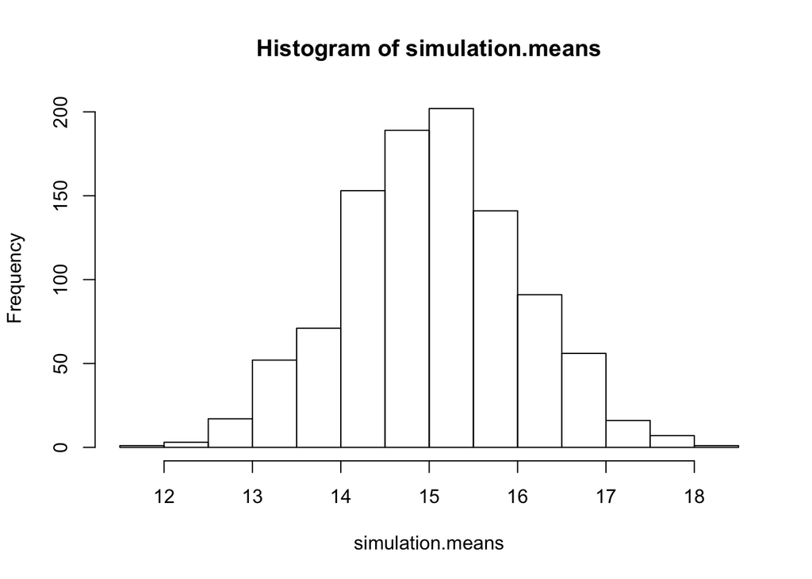

```r
num.simulations <- 1000
simulation.means <- apply(matrix(runif(num.simulations*num.samples,
                                 min=population.min,
                                 max=population.max),
                                 nrow=num.simulations),
                          MARGIN=1,
                          FUN=mean)
sd.of.sample.means <- sd(simulation.means)
hist(simulation.means)
```

Indeed the distribution of sample means looks fairly Gaussian. The standard deviation of the samples means is 1.0067, which agrees with the expected standard deviation of 1.

## Question 7

Consider a standard uniform density. The mean for this density is .5 and the variance is 1 / 12. You sample 1,000 observations from this distribution and take the sample mean, what value would you expect it to be near?

The sample mean is expected to be near 0.5.

We can show this by running toy simulations:

```r
print(mean(runif(1000, min=0, max=1)))
```

```
## [1] 0.4907
```

```r
print(mean(runif(1000, min=0, max=1)))
```

```
## [1] 0.5207
```

```r
print(mean(runif(1000, min=0, max=1)))
```

```
## [1] 0.4972
```

Indeed, the three test simulations were near the expected value of 0.5, however, we can be a bit more rigorous.

```r
num.simulations <- 100
n.samples <- 1000
mean(apply(matrix(runif(num.simulations*n.samples, min=0, max=1),
                  nrow=num.simulations),
           1, mean))
```

```
## [1] 0.499
```

## Question 8

The number of people showing up at a bus stop is assumed to be Poisson with a mean of 5 people per hour. You watch the bus stop for 3 hours. About what’s the probability of viewing 10 or fewer people?

```r
hourly.exp <- 5
num.hours <- 3
total.exp <- hourly.exp*num.hours
```

The expected number of people to view in 3 is 15. This can be modeled as a Poisson.

```r
ppois(10, lambda=total.exp)
```

```
## [1] 0.1185
```

We can test this explicitly by taking the sum of all the densities less than or equal to 10

```r
sum(dpois(0:10, lambda=total.exp))
```

```
## [1] 0.1185
```